# Soil vs Feces Microbial Diversity

Quintana_Theresa

## Repository

github.com/taq-poly/Quintana_CBC26

## Data Provenance

- **Source publication:** Caporaso, J.G., et al. (2011). *Global patterns of 16S rRNA diversity at a depth of millions of sequences per sample.* PNAS 108: 4516–4522.
- **What it is:** 16S rRNA gene sequencing of 25 environmental and human-associated samples plus mock communities.
- **How it got here:** distributed as the `GlobalPatterns` example dataset bundled inside the `phyloseq` R/Bioconductor package — loaded directly via `data(GlobalPatterns)`, no external download or URL involved.
- **What this analysis uses:** just the OTU count table and the `SampleType` metadata column, restricted to Soil (n=3) and Feces (n=4) samples for the main claim.

## Claim

Soil samples have higher microbial diversity (Shannon index) than human feces samples, using the `GlobalPatterns` 16S dataset described above.

```r
#load libraries
library(phyloseq) #organize microbiome data
library(vegan) #ecology math
data(GlobalPatterns)                                    # loads the built-in GlobalPatterns dataset into R session
otu <- as(otu_table(GlobalPatterns), "matrix")           # pulls out the OTU count table (taxa x samples) as a plain matrix
samp <- as(sample_data(GlobalPatterns), "data.frame")    # pulls out the sample metadata (e.g. SampleType) as a data frame
```

## Main analysis

```r
shannon <- vegan::diversity(t(otu), index = "shannon")     # compute Shannon diversity for every sample (t() flips otu so samples are rows, taxa are columns -- vegan expects samples as rows)

df <- data.frame(sample = names(shannon), shannon = as.numeric(shannon),  # build a tidy data frame: one row per sample
                  type = samp[names(shannon), "SampleType"])              # attach each sample's SampleType (Soil/Feces/etc.) by matching sample names

soil  <- df$shannon[df$type == "Soil"]    # pull out just the Shannon values for Soil samples
feces <- df$shannon[df$type == "Feces"]   # pull out just the Shannon values for Feces samples

observed_diff <- mean(soil) - mean(feces)  # the actual effect size: how much higher soil diversity is than feces diversity

cat("Soil mean:", mean(soil), " Feces mean:", mean(feces), "\n")  # print both group means to eyeball before the formal test
```

```
## Soil mean: 6.617205  Feces mean: 3.673836
```

```r
wilcox.test(soil, feces)   # nonparametric test comparing the two groups -- appropriate here since n is tiny (3 vs 4), too small to assume normality
```

```
##
##  Wilcoxon rank sum exact test
##
## data:  soil and feces
## W = 12, p-value = 0.05714
## alternative hypothesis: true location shift is not equal to 0
```

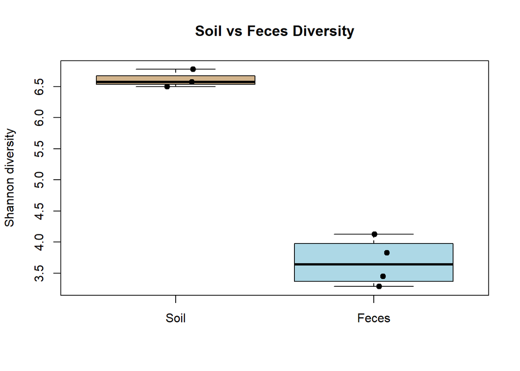

```r
#plot shannon
boxplot_shannon <- boxplot(soil, feces, names = c("Soil", "Feces"),
        ylab = "Shannon diversity", main = "Soil vs Feces Diversity",
        col = c("tan", "lightblue"))
stripchart(list(Soil = soil, Feces = feces), vertical = TRUE,
           method = "jitter", pch = 19, add = TRUE)
```

```r
boxplot_shannon
```

```
## $stats
##          [,1]     [,2]
## [1,] 6.498494 3.287666
## [2,] 6.537506 3.370219
## [3,] 6.576517 3.640570
## [4,] 6.676560 3.977453
## [5,] 6.776603 4.126538
##
## $n
## [1] 3 4
##
## $conf
##          [,1]     [,2]
## [1,] 6.449670 3.160855
## [2,] 6.703365 4.120285
##
## $out
## numeric(0)
##
## $group
## numeric(0)
##
## $names
## [1] "Soil"  "Feces"
```

## Control 1: Known answer

A perfectly even community of 4 taxa has Shannon = ln(4) (Shannon diversity is maximized when a community is perfectly even, and for N equally-abundant categories, that maximum value is always ln(N)). Here we check the pipeline against a fact we can prove on paper, so any bug in the diversity calculation itself would show up here first.

```r
cat("Expected: ln(4) =", log(4), " | Pipeline gives:", vegan::diversity(rep(10, 4)), "\n")  # compare the math answer (log(4), computed independently of vegan) side-by-side with what vegan::diversity() returns for an even 4-taxa community (10,10,10,10)
```

```
## Expected: ln(4) = 1.386294  | Pipeline gives: 1.386294
```

## Control 2: Invariant - has to be true

Shannon diversity must be non-negative for every sample. It’s checking a property that has to hold true regardless of what the actual biology turns out to be, since Shannon entropy can never be negative by definition.

```r
all(shannon >= 0)   # TRUE only if every sample's Shannon value is >= 0 -- checks all 26 samples at once, not just soil/feces
```

```
## [1] TRUE
```

## Control 3: Negative control

A negative control checks that a result disappears once you break the thing that’s supposedly causing it – here, that means scrambling which label goes with which sample and confirming the soil/feces difference goes away.

**Destroyed:** which label (Soil/Feces) is attached to which diversity value. **Preserved:** the real diversity values themselves. Shuffle labels 1000 times, build a null distribution.

```r
sf <- df[df$type %in% c("Soil", "Feces"), ]   # subset down to just the 7 soil+feces rows (drops Mock/Skin/Tongue/etc.)

null_diffs <- replicate(1000, {                                              # repeat the whole block 1000 times, collecting each result. Note that there are really only like 35 different possible ways to relabel 7 samples
  shuffled <- sample(sf$type)                                               # randomly reshuffle which label (Soil/Feces) goes with which row -- breaks the real pairing
  mean(sf$shannon[shuffled == "Soil"]) - mean(sf$shannon[shuffled == "Feces"])  # compute the same statistic as the main analysis, but on fake/shuffled labels
})

cat("Null mean:", mean(null_diffs), "(should be ~0)\n")   # average of all 1000 fake differences -- should hover near 0 if there's really no effect once labels are randomized
```

```
## Null mean: 0.02445608 (should be ~0)
```

```r
cat("Empirical p-value:", mean(abs(null_diffs) >= abs(observed_diff)), "\n")  # what fraction of the 1000 fake differences were as extreme as (or more extreme than) our real observed difference
```

```
## Empirical p-value: 0.028
```

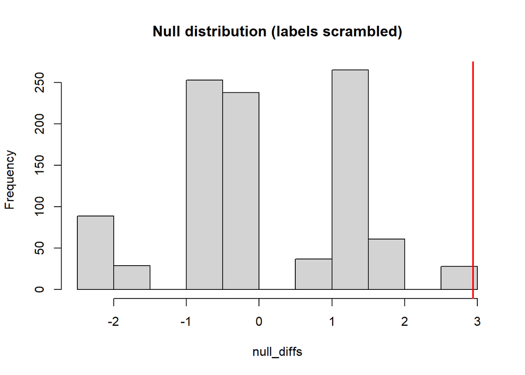

```r
hist(null_diffs, main = "Null distribution (labels scrambled)")   # plot the 1000 fake differences as a histogram
abline(v = observed_diff, col = "red", lwd = 2)                   # draw a red vertical line at the real observed difference, so you can see where it falls relative to the null
```

## Control 4: Positive control

A positive control is the mirror image of the negative control – instead of destroying a real effect and checking it disappears, you plant a fake effect you know is there and check that your pipeline actually catches it.

**Planted:** take one real feces sample, truncate it to its top 20 taxa (deliberately less diverse), and confirm the test finds that difference against the untouched full community.

```r
base <- sort(otu[otu[, "M31Fcsw"] > 0, "M31Fcsw"], decreasing = TRUE)   # grab one real feces sample's counts, drop zero-count taxa, sort most-to-least abundant

p_full <- base / sum(base)   # convert counts to proportions -- the real, untouched community's abundance distribution

p_trunc <- rep(0, length(base)); p_trunc[1:20] <- base[1:20]; p_trunc <- p_trunc / sum(p_trunc)
# build a deliberately less-diverse version: start with all zeros, keep only the top 20 most abundant taxa's counts, zero out everything else, then renormalize to proportions

A <- apply(rmultinom(5, 5000, p_full),  2, vegan::diversity)  # untouched: draw 5 synthetic samples (5000 reads each) from the full community, compute Shannon for each
B <- apply(rmultinom(5, 5000, p_trunc), 2, vegan::diversity)  # planted low-diversity: same thing, but drawing from the truncated (top-20-only) community

cat("Full mean:", mean(A), " Truncated mean:", mean(B), "\n")   # compare average diversity between the two groups
```

```
## Full mean: 3.745362  Truncated mean: 2.446566
```

```r
wilcox.test(A, B)   # test whether that planted difference is statistically detectable
```

```
##
##  Wilcoxon rank sum exact test
##
## data:  A and B
## W = 25, p-value = 0.007937
## alternative hypothesis: true location shift is not equal to 0
```

## Control 5: Redundancy

Computing Shannon diversity two ways: `vegan::diversity()` vs. a hand-written formula. They share the same input data and the same math definition — but not the same code, so a bug specific to one implementation (wrong axis, forgetting to drop zero counts, etc.) would show up as a mismatch here.

```r
manual_shannon <- function(x) { p <- x[x > 0] / sum(x); -sum(p * log(p)) }
# hand-written Shannon formula: drop zero-count taxa, convert counts to proportions (p),
# then compute -sum(p * log(p)) directly -- the textbook definition, no vegan involved

cat("vegan:  ", vegan::diversity(otu[, "CL3"]), "\n")    # Shannon diversity for one real soil sample (CL3), via vegan's built-in function
```

```
## vegan:   6.576517
```

```r
cat("manual: ", manual_shannon(otu[, "CL3"]), "\n")      # same sample, same math, computed by the from-scratch formula above
```

```
## manual:  6.576517
```

## Control 6: Order of magnitude

Soil diversity should be clearly higher than feces diversity, since soil habitats are generally far more microbially diverse than host-filtered gut communities. The results (mean Shannon diversity: soil = 6.62, feces = 3.67, computed in the main analysis chunk above) show that soil samples do in fact have noticeably higher diversity than feces samples, matching what was expected going in.

## Control 7: Determinism

Running the same calculation twice and confirming the results are exactly identical. If they weren’t, that would mean something in the pipeline depends on unseeded randomness or some other source of variability, which would undermine trust in every other result above.

```r
r1 <- vegan::diversity(t(otu[, c("CL3", "M31Fcsw")]))   # compute Shannon diversity for two samples (one soil, one feces)
r2 <- vegan::diversity(t(otu[, c("CL3", "M31Fcsw")]))   # run the exact same calculation again, from scratch
identical(r1, r2)   # TRUE only if both runs produced exactly the same numbers, down to the last decimal
```

```
## [1] TRUE
```

*This analysis script was developed with the assistance of Claude (Anthropic), which helped design the control structure, write and debug the R code, and explain the statistical/biological reasoning behind each step. All code was run and results verified before inclusion.*